# An Introduction to Insurance Pricing, GLMs and Model Validation

DataFest Tbilisi 2020

Mick Cooney mickcooney@gmail.com

2020-05-23

# Background

[figure not shown]

## Insurance Business

Life Insurance

General Insurance

(Health Insurance)

Pay premia

If event occurs, receive payout

How do we calculate premia?

How *SHOULD* we calculate premia?

$$\text{Price} = E(\text{Loss}) + \text{Expenses} + \text{Profit}$$

## Life Insurance

Monthly or annual premia

Contingent annuity

Life Tables

## Pricing General Insurance

Typically 1-year policies

(but not always)

Estimate Loss Cost of a Policy

Frequency / Severity Model

Exposure vs Claims

Heavy use of GLMs

$$\text{Price} = E[\text{Claim Rate}] \times E[\text{Claim Size}]$$

Claim Rate $\longrightarrow$ Poisson

Claim Amount $\longrightarrow$ Gamma

Need policy and claim data

Package `CASDatasets`

`freMPTLfreq` and `freMPTLsev`

More datasets in book

# Data Loading and Exploration

| PolicyID | ClaimNb | Exposure | Power | CarAge | DriverAge | Brand | Gas | Region | Density |
| --- | --- | --- | --- | --- | --- | --- | --- | --- | --- |
| 1 | 0 | 0.09 | g | 0 | 46 | Japanese (except Nissan) or Korean | Diesel | Aquitaine | 76 |
| 2 | 0 | 0.84 | g | 0 | 46 | Japanese (except Nissan) or Korean | Diesel | Aquitaine | 76 |
| 3 | 0 | 0.52 | f | 2 | 38 | Japanese (except Nissan) or Korean | Regular | Nord-Pas-de-Calais | 3003 |
| 4 | 0 | 0.45 | f | 2 | 38 | Japanese (except Nissan) or Korean | Regular | Nord-Pas-de-Calais | 3003 |
| 5 | 0 | 0.15 | g | 0 | 41 | Japanese (except Nissan) or Korean | Diesel | Pays-de-la-Loire | 60 |
| 6 | 0 | 0.75 | g | 0 | 41 | Japanese (except Nissan) or Korean | Diesel | Pays-de-la-Loire | 60 |

```
## Rows: 413,169
## Columns: 10
## $ PolicyID  <fct> 1, 2, 3, 4, 5, 6, 7, 8, 9, 10, 11, 12, 13, 14, 15, 16, 17, …
## $ ClaimNb   <int> 0, 0, 0, 0, 0, 0, 0, 0, 0, 0, 0, 0, 0, 0, 0, 0, 0, 0, 0, 0,…
## $ Exposure  <dbl> 0.09, 0.84, 0.52, 0.45, 0.15, 0.75, 0.81, 0.05, 0.76, 0.34,…
## $ Power     <fct> g, g, f, f, g, g, d, d, d, i, f, f, e, e, e, e, e, e, i, i,…
## $ CarAge    <int> 0, 0, 2, 2, 0, 0, 1, 0, 9, 0, 2, 2, 0, 0, 0, 0, 0, 0, 0, 0,…
## $ DriverAge <int> 46, 46, 38, 38, 41, 41, 27, 27, 23, 44, 32, 32, 33, 33, 33,…
## $ Brand     <fct> Japanese (except Nissan) or Korean, Japanese (except Nissan…
## $ Gas       <fct> Diesel, Diesel, Regular, Regular, Diesel, Diesel, Regular, …
## $ Region    <fct> Aquitaine, Aquitaine, Nord-Pas-de-Calais, Nord-Pas-de-Calai…
## $ Density   <int> 76, 76, 3003, 3003, 60, 60, 695, 695, 7887, 27000, 23, 23, …
```

| PolicyID | ClaimAmount |
| --- | --- |
| 63987 | 1172 |
| 310037 | 1905 |
| 314463 | 1150 |
| 318713 | 1220 |
| 309380 | 55077 |
| 309380 | 7593 |
| 318738 | 1176 |
| 305914 | 1202 |
| 313314 | 1203 |
| 309238 | 1232 |
| 314567 | 1224 |
| 308695 | 574 |
| 310208 | 1206 |
| 314049 | 1134 |
| 308943 | 1200 |

## Combine Tables

| policy_id | claim_nb | exposure | power | car_age | driver_age | brand | gas | region | density | claim_count | claim_total |
| --- | --- | --- | --- | --- | --- | --- | --- | --- | --- | --- | --- |
| 1 | 0 | 0.09 | g | 0 | 46 | Japanese (except Nissan) or Korean | Diesel | Aquitaine | 76 | 0 | 0 |
| 2 | 0 | 0.84 | g | 0 | 46 | Japanese (except Nissan) or Korean | Diesel | Aquitaine | 76 | 0 | 0 |
| 3 | 0 | 0.52 | f | 2 | 38 | Japanese (except Nissan) or Korean | Regular | Nord-Pas-de-Calais | 3003 | 0 | 0 |
| 4 | 0 | 0.45 | f | 2 | 38 | Japanese (except Nissan) or Korean | Regular | Nord-Pas-de-Calais | 3003 | 0 | 0 |
| 5 | 0 | 0.15 | g | 0 | 41 | Japanese (except Nissan) or Korean | Diesel | Pays-de-la-Loire | 60 | 0 | 0 |
| 6 | 0 | 0.75 | g | 0 | 41 | Japanese (except Nissan) or Korean | Diesel | Pays-de-la-Loire | 60 | 0 | 0 |

```r
combined_tbl %>% filter(claim_nb != claim_count)
```

```
## # A tibble: 0 x 12
## # … with 12 variables: policy_id <chr>, claim_nb <int>, exposure <dbl>,
## #   power <fct>, car_age <int>, driver_age <int>, brand <fct>, gas <fct>,
## #   region <fct>, density <int>, claim_count <int>, claim_total <int>
```

## Univariate Data Exploration

Look at each variable

Create histograms, bar charts etc

`dataexpks` - data exploration template

### claim_count

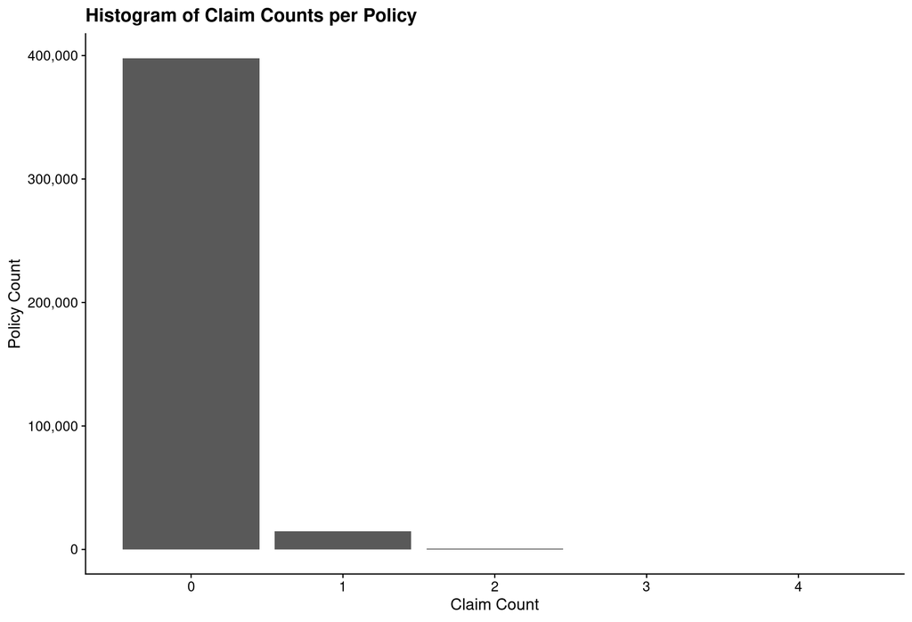

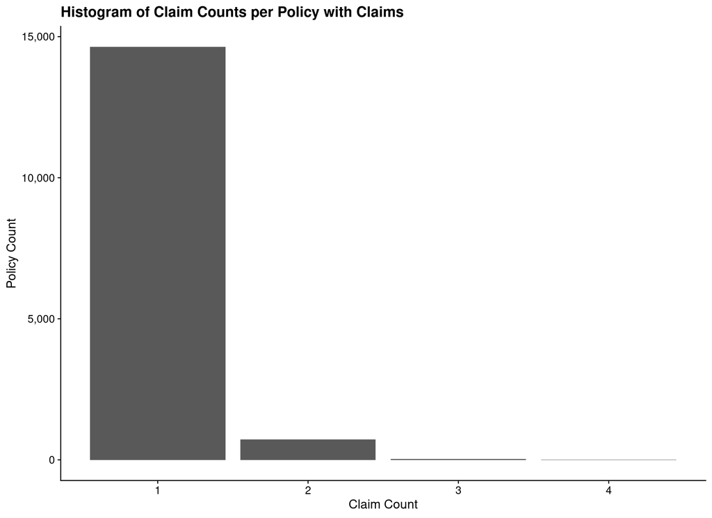

### claim_amount

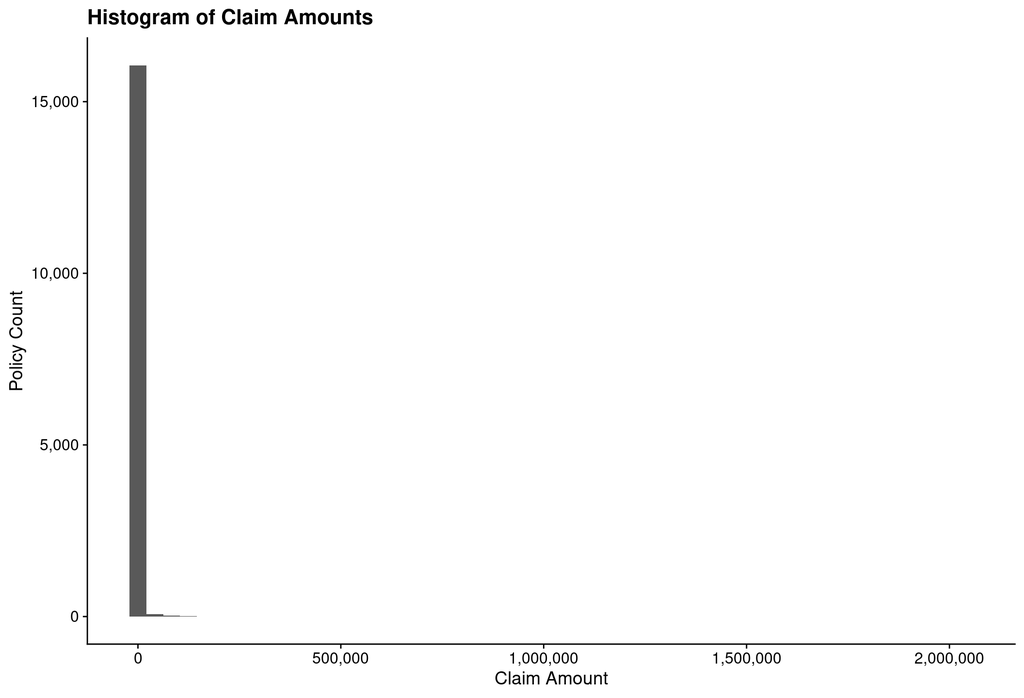

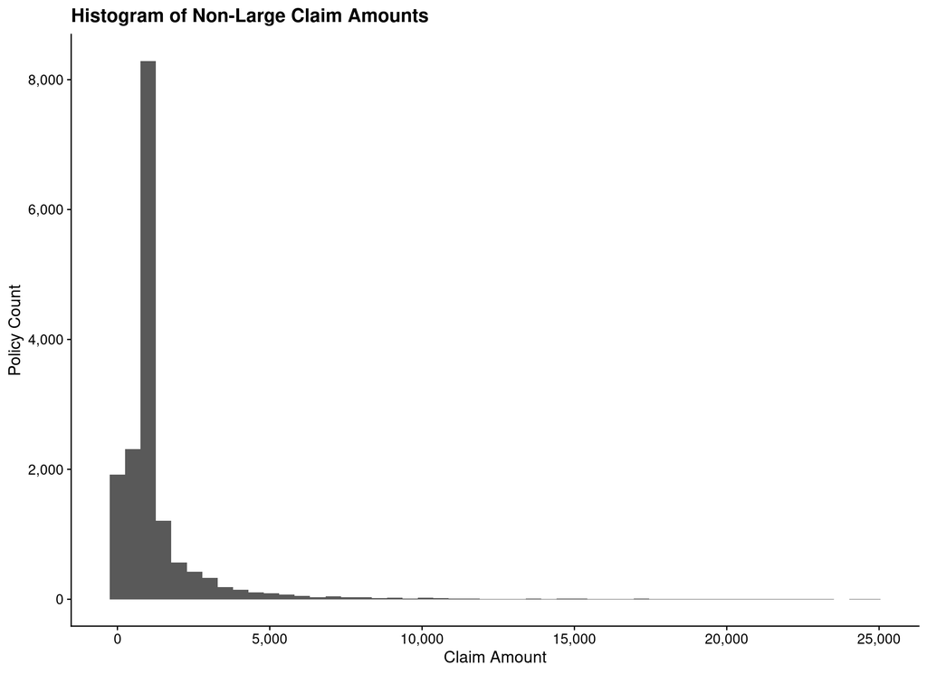

### exposure

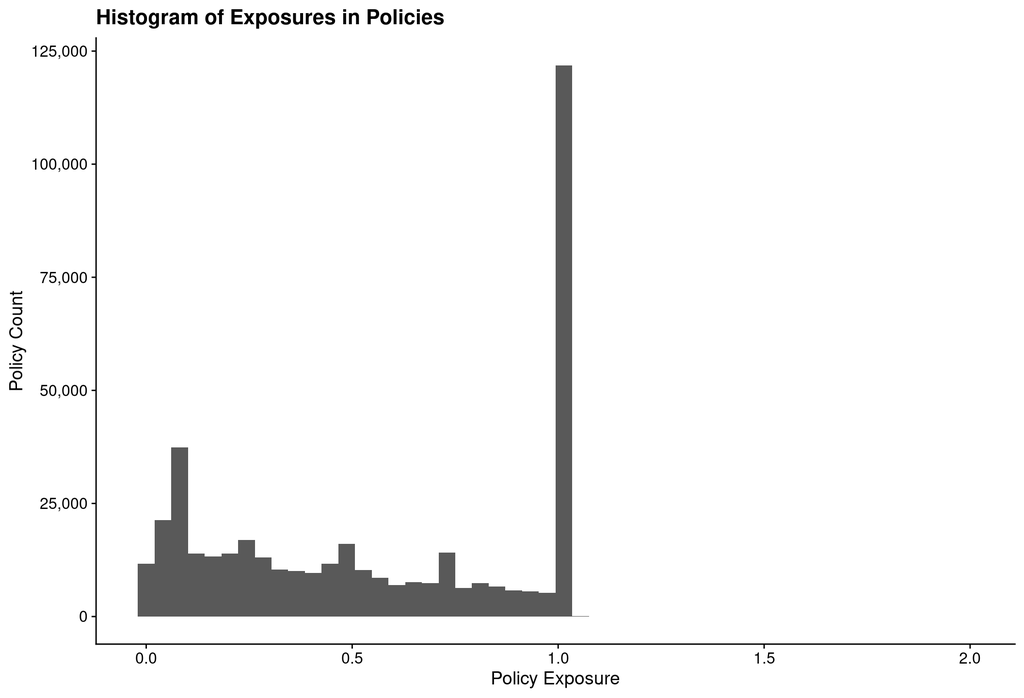

### driver_age

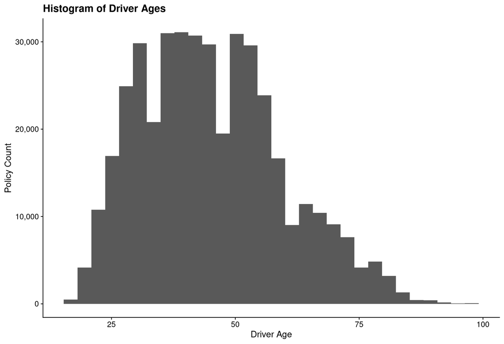

### car_age

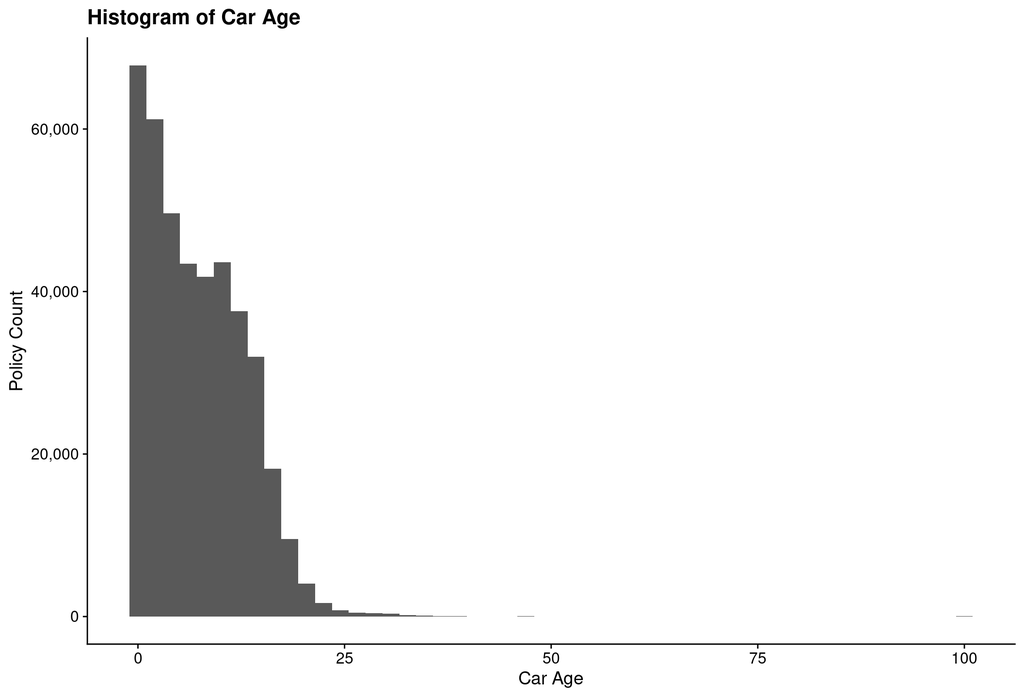

### region

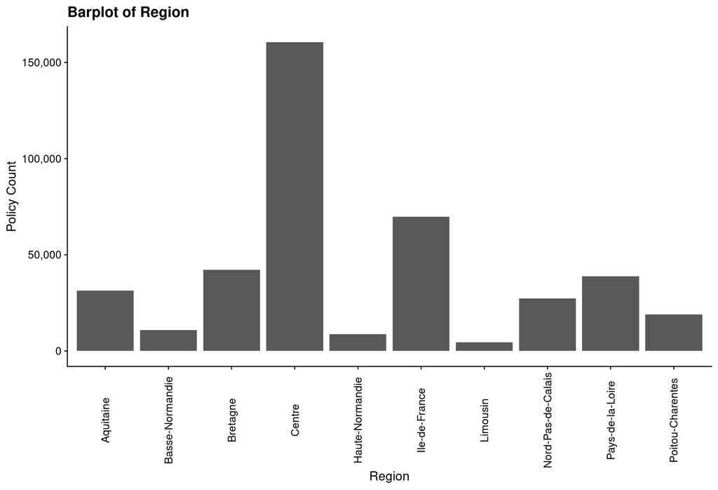

## Bivariate Data Exploration

Look at two variables at once

Boxplots, Scatterplots, Heatmaps, etc

### claim_count vs driver_age

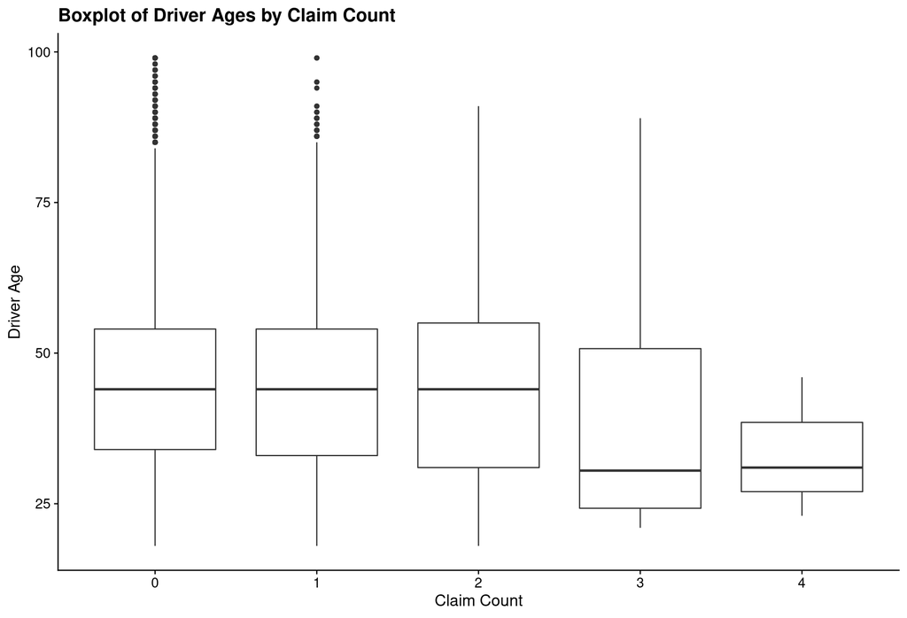

### claim_count vs region

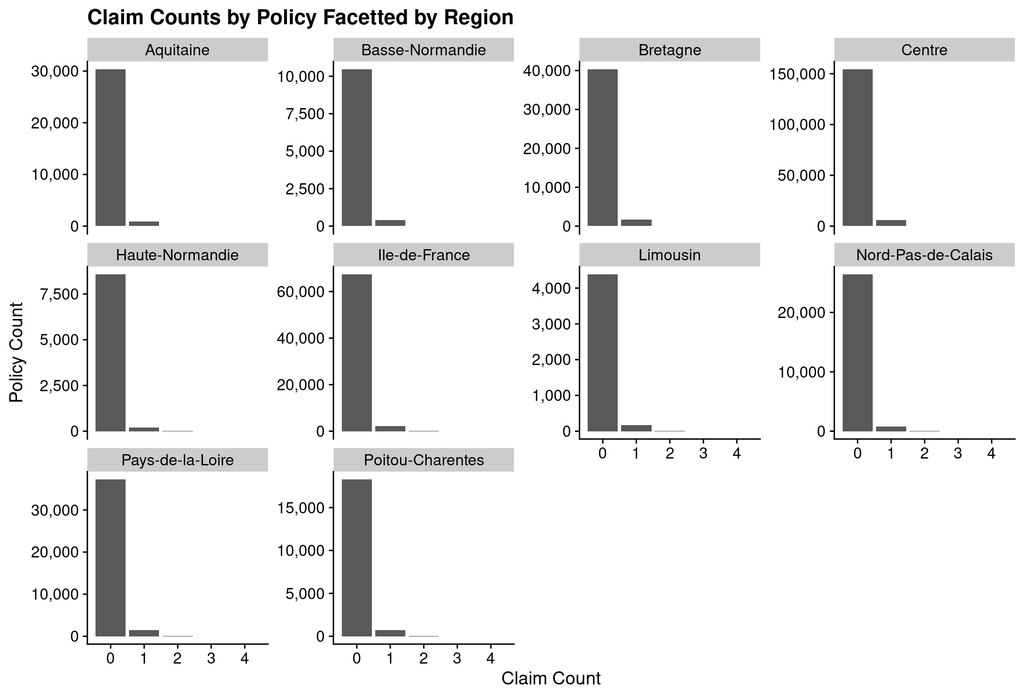

## Estimating Large Losses

Power-law scaling

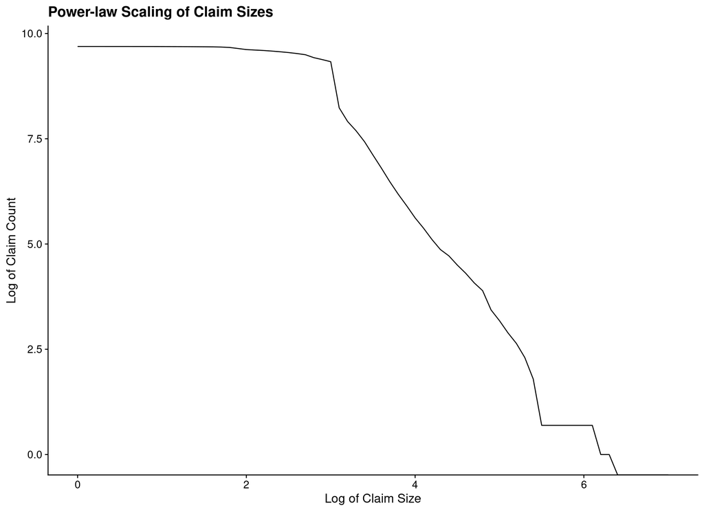

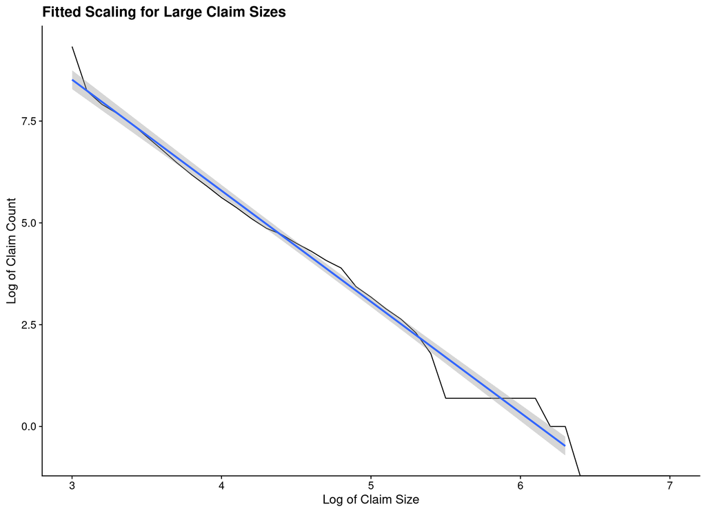

Slope is scaling factor, $\alpha$

$\alpha > 2 \; \implies \mu$ finite

$\alpha > 3 \; \implies$ variance finite

Definitely want finite $\mu$…

```r
pl_tbl <- powerlaw_tbl %>%
  filter(logsize >= 3, count > 0) %>%
  mutate(logcount  = log(count))

pl_lm <- lm(logcount ~ logsize, data = pl_tbl)
```

| term | estimate | std.error | statistic | p.value |
| --- | --- | --- | --- | --- |
| (Intercept) | 16.695158 | 0.2806576 | 59.48585 | 0 |
| logsize | -2.726148 | 0.0590564 | -46.16179 | 0 |

Finite $\mu$, non-finite $\text{Var}(x)$

# Proposed Approach

## Model Attritional Losses

Use Poisson / Gamma models for rate / size

Estimate of attritional loss cost

Each policy has ‘fitted’ estimate

## Model Catastrophic Losses

Use power-law distribution

Estimate rate of large losses

Use mean loss to calculate flat charge

## Calculate Price

‘Technical’ price

$$P_{\text{Technical}} = P_{\text{Attritional}} + P_{\text{Catastrophic}}$$

## Known Limitations

May want “Large Loss” piece - not in data

No consideration of market realities

# Generalized Linear Models

## Basic Concept

$$\begin{eqnarray*}
E(\mathbf{Y}) &=& \mu = g^{-1}(\text{X} \beta) \\
\text{Var}(\mathbf{Y}) &=& V(\mu)
\end{eqnarray*}$$

where

$$\begin{align*}
\mathbf{Y} &= \text{response variable} \\
\mathbf{X} &= \text{predictor variables} \\
\beta &= \text{model coefficients} \\
g(x) &= \text{link function} \\
V(x) &= \text{variance function} \\
\end{align*}$$

Combines multiple forms of regression

$$\begin{eqnarray*}
\text{Linear regression} &\longrightarrow & g(x) = x \\
\\
\text{Poisson regression} &\longrightarrow & g(x) = \log(x) \\
\\
\text{Gamma regression} &\longrightarrow & g(x) = \frac{1}{x}
\end{eqnarray*}$$

## Modelling Claim Rate

Predict per-policy poisson rate

### Overall Claim Rate

```r
combined_tbl %>%
  summarise(claim_rate = sum(claim_count) / sum(exposure)) %>%
  pull(claim_rate)
```

```
## [1] 0.06979859
```

### Claim Rate by Region

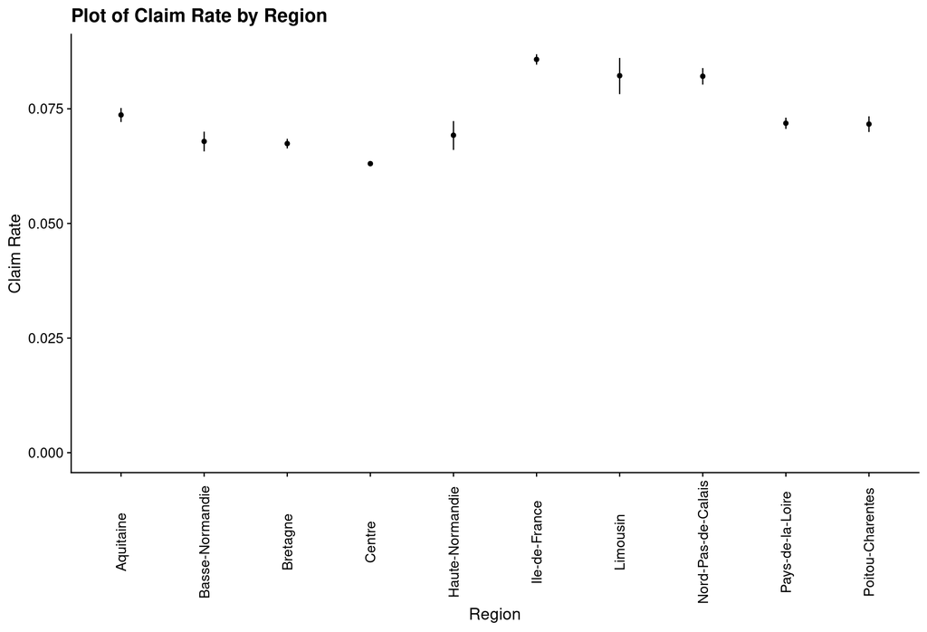

### Claim Rate by Driver Age

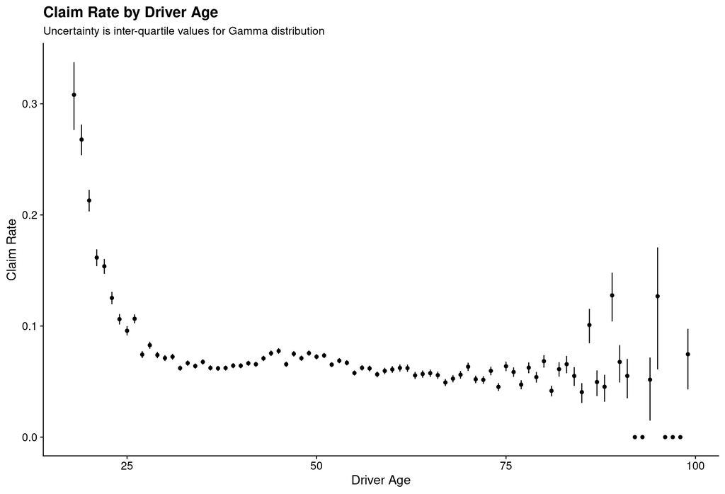

Non-linear relationship

### Categorise Driver Age

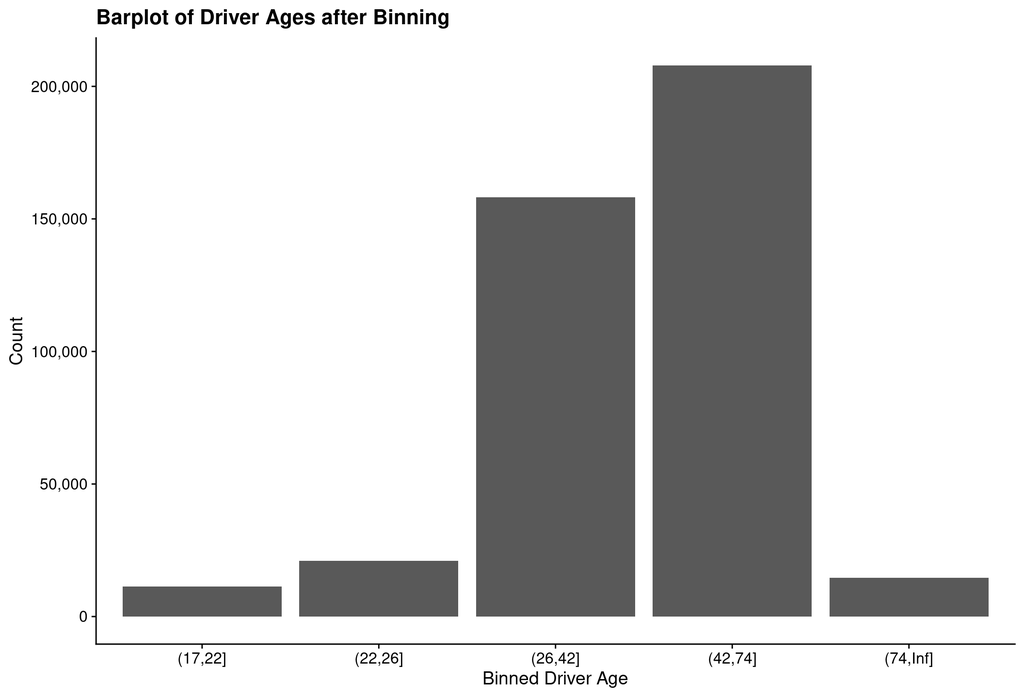

### First Poisson Model

```r
gas_glm <- glm(claim_nb ~ 0 + gas,
               offset = log(exposure),
               data   = policy_tbl,
               family = poisson)
```

#### Model Diagnostics

| diagnostic | value |
| --- | --- |
| null.deviance | 450746.76 |
| df.null | 413169.00 |
| logLik | -68397.29 |
| AIC | 136798.57 |
| BIC | 136820.44 |
| deviance | 105537.45 |
| df.residual | 413167.00 |

#### Model Coefficients

| term | estimate | std.error | statistic | p.value |
| --- | --- | --- | --- | --- |
| gasDiesel | -2.5946 | 0.0109 | -238.4543 | 0 |
| gasRegular | -2.7310 | 0.0114 | -240.1932 | 0 |

### Adding Driver Age

```r
expmodel2_glm <- glm(claim_nb ~ gas + cat_driver_age,
                     offset = log(exposure),
                     data   = policy_tbl,
                     family = poisson)
```

#### Model Diagnostics

| diagnostic | value |
| --- | --- |
| null.deviance | 105612.65 |
| df.null | 413168.00 |
| logLik | -67951.54 |
| AIC | 135915.08 |
| BIC | 135980.67 |
| deviance | 104645.96 |
| df.residual | 413163.00 |

#### Model Coefficients

| term | estimate | std.error | statistic | p.value |
| --- | --- | --- | --- | --- |
| (Intercept) | -2.6369 | 0.0152 | -173.8980 | 0.0000 |
| gasRegular | -0.1488 | 0.0159 | -9.3752 | 0.0000 |
| cat_driver_age(17,22] | 1.0630 | 0.0364 | 29.2362 | 0.0000 |
| cat_driver_age(22,26] | 0.4790 | 0.0342 | 14.0061 | 0.0000 |
| cat_driver_age(42,74] | -0.0172 | 0.0175 | -0.9831 | 0.3255 |
| cat_driver_age(74,Inf] | -0.0913 | 0.0419 | -2.1785 | 0.0294 |

### The “Secret Weapon”

Andrew Gelman

Train model on data splits

Plot parameters together

[figure not shown]

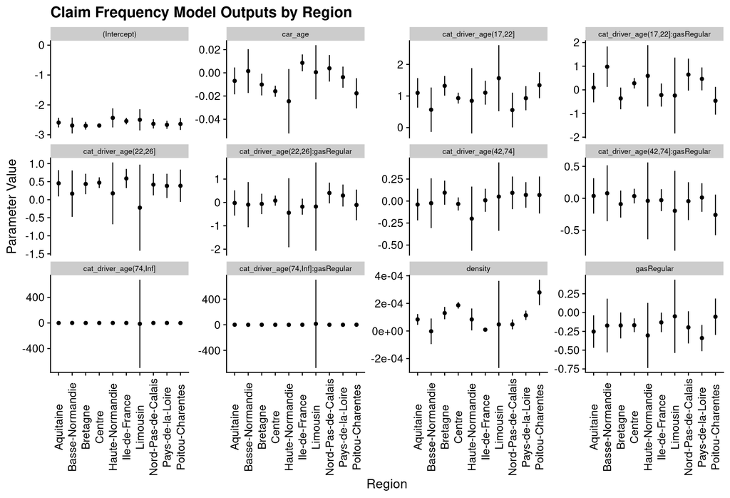

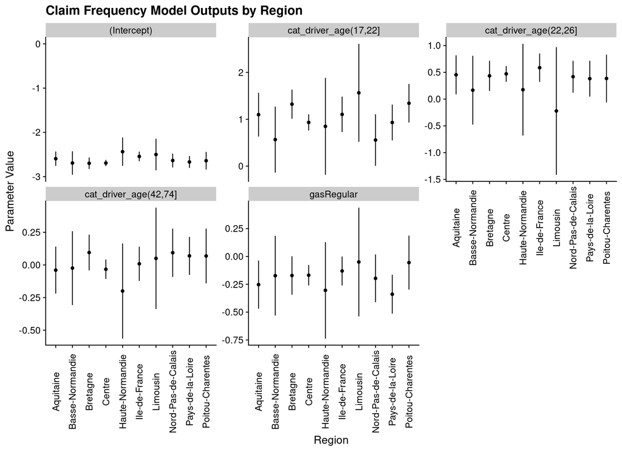

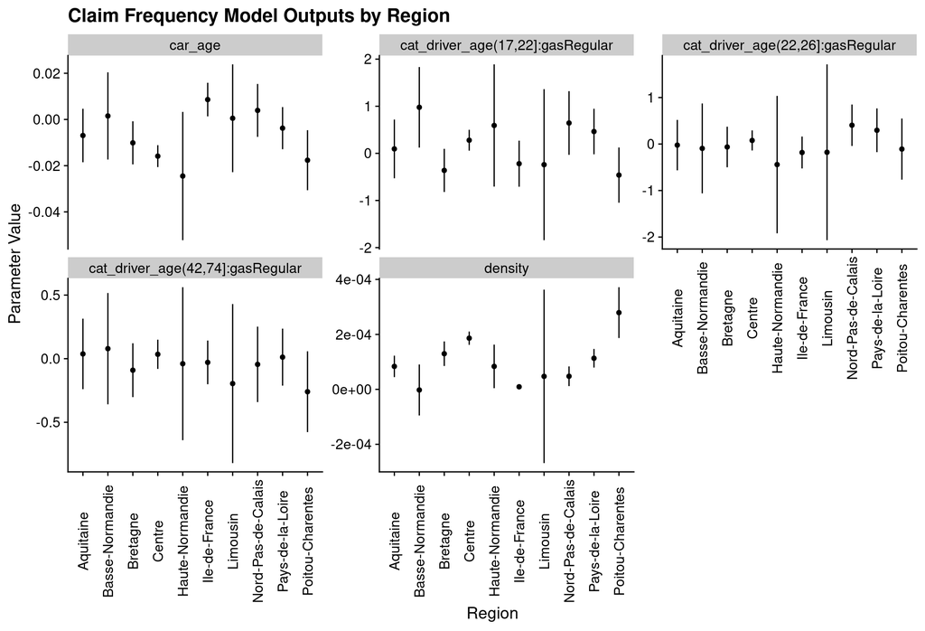

## Modelling Claim Size

Claim size always positive

Take logs?

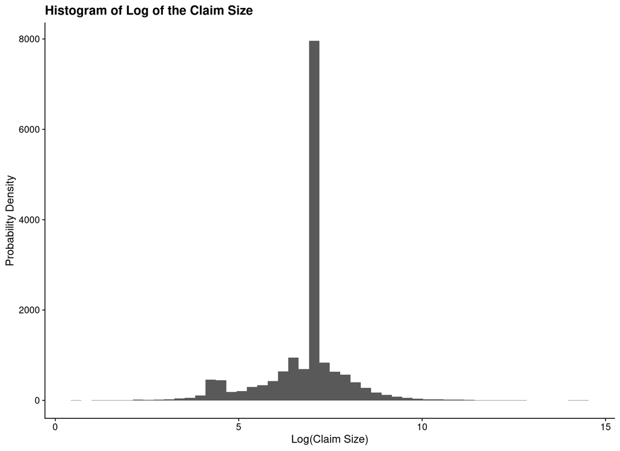

### Linear Model of Log(Claim Size)

```r
expclaim_lm <- lm(log(claim_amount) ~ gas + power + car_age,
                  data = claimreg_tbl)
```

#### Model Diagnostics

| diagnostic | value |
| --- | --- |
| r.squared | 0.0017 |
| adj.r.squared | 0.0009 |
| sigma | 1.1147 |
| statistic | 2.1411 |
| p.value | 0.0096 |
| df | 14.0000 |
| logLik | -24710.1416 |
| AIC | 49450.2831 |
| BIC | 49565.6570 |
| deviance | 20089.1027 |
| df.residual | 16167.0000 |

#### Model Coefficients

| term | estimate | std.error | statistic | p.value |
| --- | --- | --- | --- | --- |
| (Intercept) | 6.87 | 0.03 | 233.18 | 0.00 |
| gasRegular | -0.01 | 0.02 | -0.60 | 0.55 |
| powere | -0.01 | 0.03 | -0.44 | 0.66 |
| powerf | 0.00 | 0.03 | 0.16 | 0.87 |
| powerg | 0.02 | 0.03 | 0.51 | 0.61 |
| powerh | 0.05 | 0.04 | 1.06 | 0.29 |
| poweri | 0.06 | 0.05 | 1.33 | 0.18 |
| powerj | 0.09 | 0.05 | 1.80 | 0.07 |
| powerk | -0.01 | 0.06 | -0.13 | 0.90 |
| powerl | 0.06 | 0.09 | 0.67 | 0.50 |
| powerm | 0.08 | 0.13 | 0.63 | 0.53 |
| powern | -0.27 | 0.15 | -1.81 | 0.07 |
| powero | -0.21 | 0.15 | -1.37 | 0.17 |
| car_age | -0.01 | 0.00 | -3.64 | 0.00 |

Multiple-$R^2$ of 0.0017???

What does that even look like?

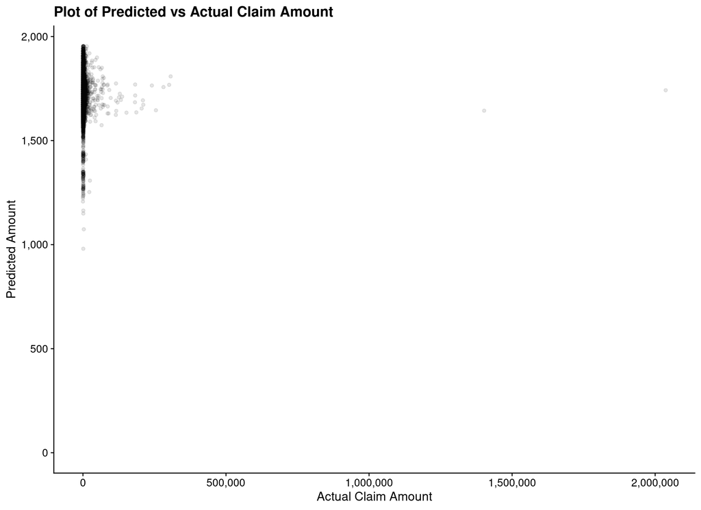

### Linear Model of Attritional Log(Claim Size)

```r
claimreg_tbl <- claimreg_tbl %>% filter(claim_amount < 25000)

expclaim2_lm <- lm(log(claim_amount) ~ gas + power + car_age,
                   data = claimreg_tbl)
```

#### Model Diagnostics

| diagnostic | value |
| --- | --- |
| r.squared | 0.0019 |
| adj.r.squared | 0.0010 |
| sigma | 1.0591 |
| statistic | 2.2948 |
| p.value | 0.0050 |
| df | 14.0000 |
| logLik | -23714.9579 |
| AIC | 47459.9158 |
| BIC | 47575.1845 |
| deviance | 18007.2982 |
| df.residual | 16054.0000 |

#### Model Coefficients

| term | estimate | std.error | statistic | p.value |
| --- | --- | --- | --- | --- |
| (Intercept) | 6.8495 | 0.0281 | 243.8822 | 0.0000 |
| gasRegular | -0.0189 | 0.0180 | -1.0492 | 0.2941 |
| powere | -0.0144 | 0.0295 | -0.4883 | 0.6254 |
| powerf | -0.0119 | 0.0289 | -0.4101 | 0.6818 |
| powerg | 0.0028 | 0.0286 | 0.0983 | 0.9217 |
| powerh | 0.0454 | 0.0409 | 1.1110 | 0.2666 |
| poweri | 0.0506 | 0.0452 | 1.1176 | 0.2638 |
| powerj | 0.0849 | 0.0457 | 1.8584 | 0.0631 |
| powerk | -0.0185 | 0.0589 | -0.3136 | 0.7538 |
| powerl | 0.0815 | 0.0865 | 0.9417 | 0.3464 |
| powerm | 0.0023 | 0.1250 | 0.0184 | 0.9853 |
| powern | -0.2481 | 0.1432 | -1.7320 | 0.0833 |
| powero | -0.1853 | 0.1459 | -1.2703 | 0.2040 |
| car_age | -0.0059 | 0.0016 | -3.6439 | 0.0003 |

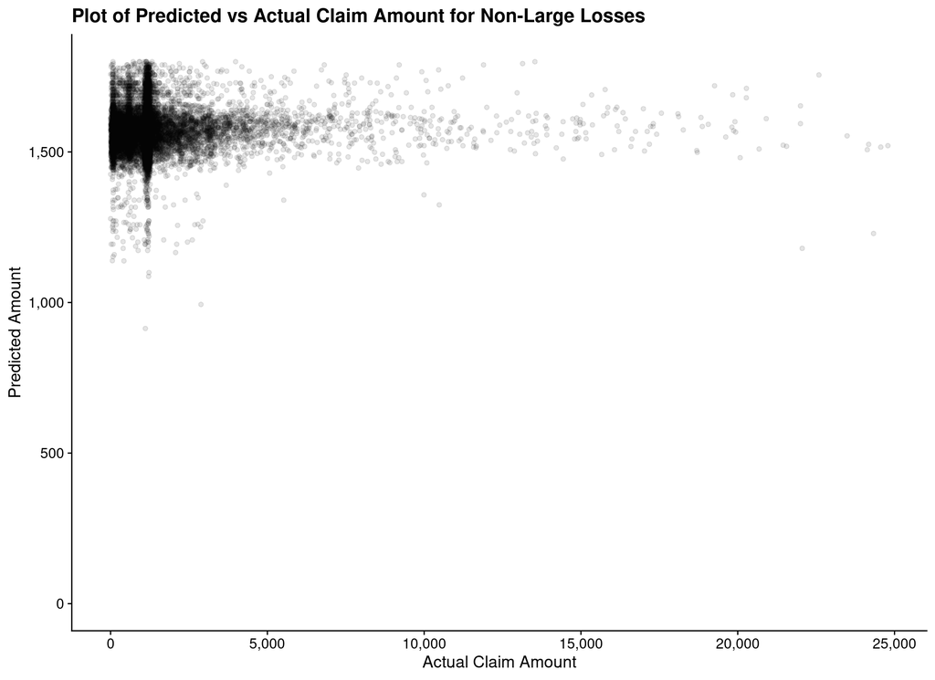

Pretty poor

Fit a Gamma?

### Gamma GLM

```r
claimgamma_glm <- glm(claim_amount ~ gas + power + car_age + cat_driver_age +
                                     cat_driver_age:power,
                      family = Gamma(link = 'log'),
                      data   = claimreg_tbl)
```

#### Model Diagnostics

| diagnostic | value |
| --- | --- |
| null.deviance | 14681.14 |
| df.null | 16067.00 |
| logLik | -132367.14 |
| AIC | 264854.29 |
| BIC | 265315.36 |
| deviance | 14470.68 |
| df.residual | 16009.00 |

#### Model Coefficients

| term | estimate | std.error | statistic | p.value |
| --- | --- | --- | --- | --- |
| powere:cat_driver_age(22,26] | -0.0061 | 0.1399 | -0.0436 | 0.9653 |
| car_age | -0.0104 | 0.0019 | -5.4276 | 0.0000 |
| powerh:cat_driver_age(22,26] | -0.0143 | 0.2235 | -0.0640 | 0.9490 |
| cat_driver_age(22,26] | -0.0152 | 0.1068 | -0.1419 | 0.8872 |
| powerk:cat_driver_age(42,74] | 0.0182 | 0.1501 | 0.1213 | 0.9035 |
| powerj:cat_driver_age(74,Inf] | -0.0266 | 0.4029 | -0.0659 | 0.9475 |
| powerl:cat_driver_age(42,74] | -0.0286 | 0.2149 | -0.1329 | 0.8943 |
| gasRegular | -0.0296 | 0.0214 | -1.3817 | 0.1671 |
| powerg:cat_driver_age(42,74] | -0.0381 | 0.0756 | -0.5048 | 0.6137 |
| poweri:cat_driver_age(17,22] | -0.0403 | 0.2266 | -0.1777 | 0.8590 |
| powerk | 0.0420 | 0.1180 | 0.3557 | 0.7221 |
| powerf | 0.0453 | 0.0589 | 0.7693 | 0.4417 |
| powere:cat_driver_age(42,74] | -0.0543 | 0.0775 | -0.7012 | 0.4832 |
| powere | 0.0561 | 0.0613 | 0.9150 | 0.3602 |
| powerj | 0.0561 | 0.0911 | 0.6161 | 0.5378 |
| powerh:cat_driver_age(42,74] | -0.0627 | 0.1053 | -0.5958 | 0.5513 |
| powerk:cat_driver_age(22,26] | -0.0692 | 0.3907 | -0.1771 | 0.8594 |
| powerf:cat_driver_age(42,74] | -0.0700 | 0.0740 | -0.9452 | 0.3446 |
| powerj:cat_driver_age(42,74] | 0.0742 | 0.1165 | 0.6368 | 0.5243 |
| cat_driver_age(42,74] | 0.0749 | 0.0594 | 1.2600 | 0.2077 |

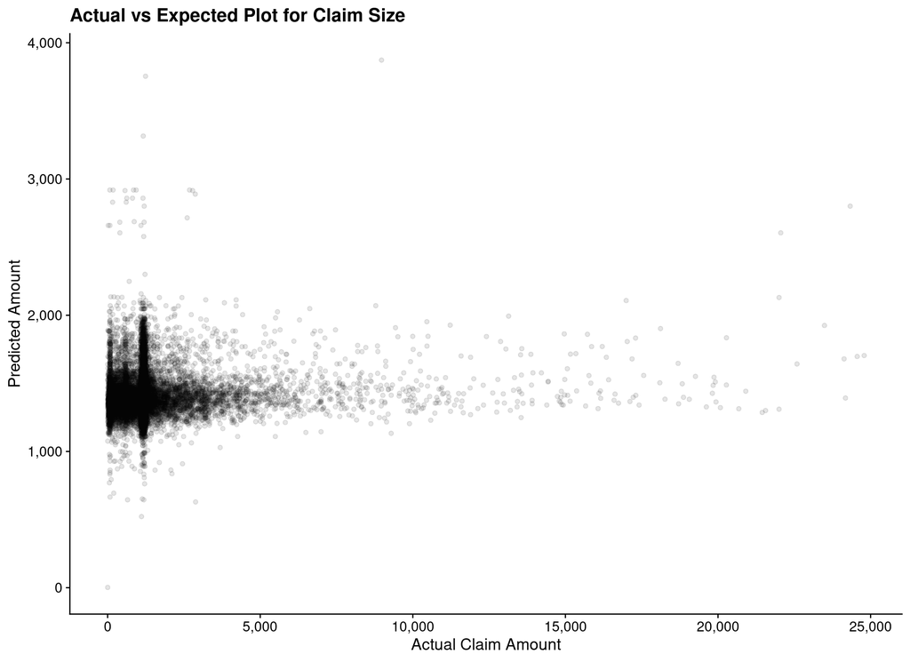

Best to have low expectations

# Model Assessment

## Assessing Frequency Models

Deviance, AIC, BIC

Simulate claim counts

Observed vs distribution of expected

## Assessing Severity Models

Claim severity skewed

Actual vs Observed inappropriate

Alternative approach required

### Proposed Claim Size Assessment

1. Per-claim gamma parameters
2. Calculate quantile for claim amount
3. Check quantile values against uniform distribution

Alternative is Q-Q plot

## Simulation of Claim Counts

Observed vs Predicted

In-Sample and Out-of-Sample

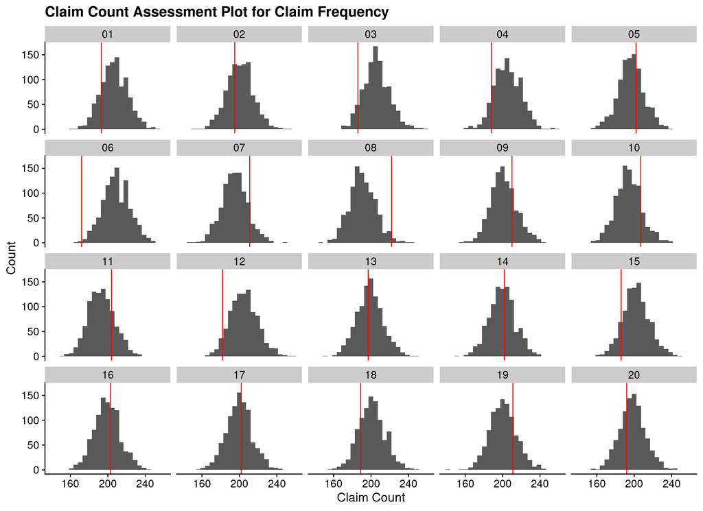

Small fold-count

Cumulative probabilities

## Simulation of Claim Size

GLM Gamma fit?

$$X \sim \Gamma(\alpha, \beta)$$

To simulate need $(\alpha, \beta)$

$$\begin{eqnarray*}
\alpha &=& \frac{1}{\text{dispersion}} \\
\beta &=& \frac{\alpha}{\mu}
\end{eqnarray*}$$

## Assessment Approach

Layers of uncertainty

### Simple Frequency/Severity

Per policy claim frequency / severity

Distribution of predicted vs observed

### Simulate Claim Counts

Simulate claim counts from claim rate

Average claim size

Multiply to calculate simulated loss cost

### Simulate Claim Count and Size

Simulate claim counts from claim rate

Simulate claim size from prediction

Multiply through for loss calculation

### Checking Claim Size Uniformity

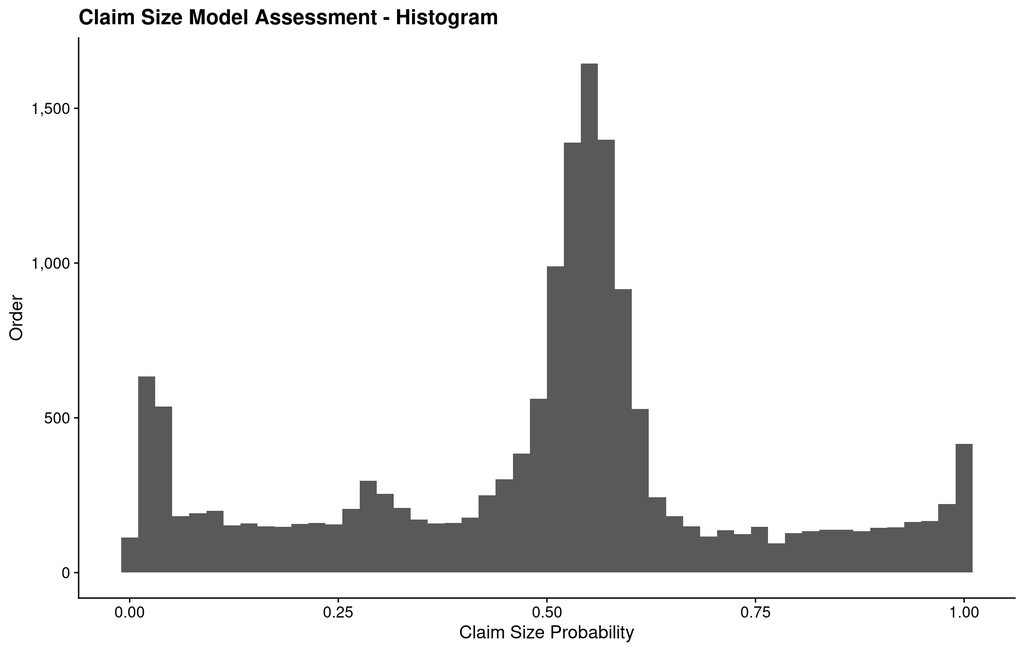

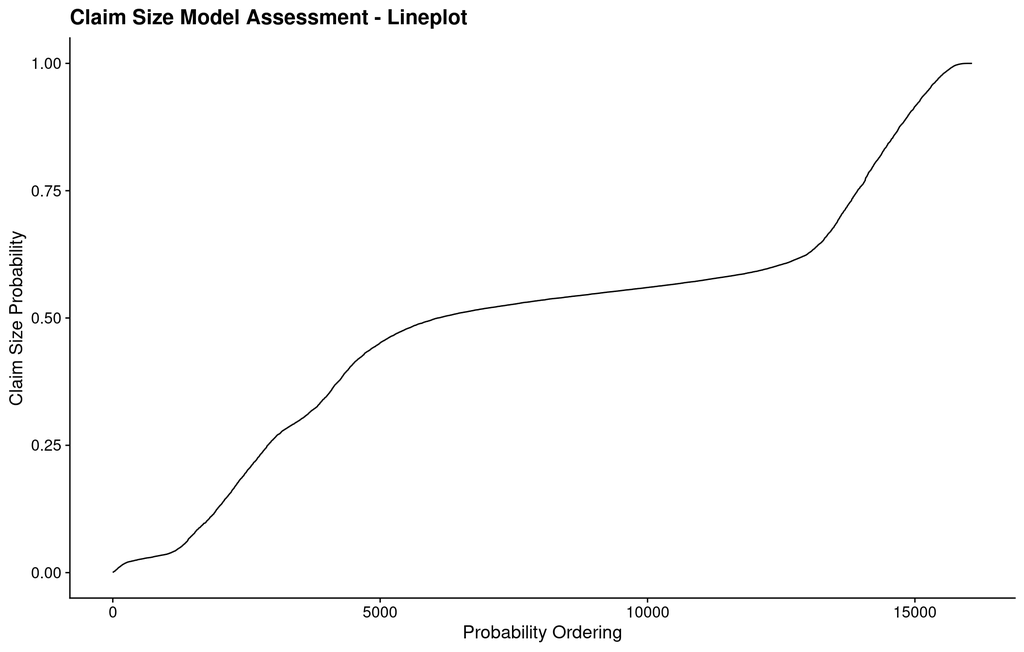

# Building a Premium Quoter

## Data Preparation

Remove drivers older than 75 years

Remove cars older than 20 years

Total size of dataset after filters: 395,068

| policy_id | claim_nb | exposure | power | car_age | driver_age | brand | gas | region | density | cat_driver_age |
| --- | --- | --- | --- | --- | --- | --- | --- | --- | --- | --- |
| 1 | 0 | 0.09 | g | 0 | 46 | Japanese (except Nissan) or Korean | Diesel | Aquitaine | 76 | (42,74] |
| 2 | 0 | 0.84 | g | 0 | 46 | Japanese (except Nissan) or Korean | Diesel | Aquitaine | 76 | (42,74] |
| 3 | 0 | 0.52 | f | 2 | 38 | Japanese (except Nissan) or Korean | Regular | Nord-Pas-de-Calais | 3003 | (26,42] |
| 4 | 0 | 0.45 | f | 2 | 38 | Japanese (except Nissan) or Korean | Regular | Nord-Pas-de-Calais | 3003 | (26,42] |
| 5 | 0 | 0.15 | g | 0 | 41 | Japanese (except Nissan) or Korean | Diesel | Pays-de-la-Loire | 60 | (26,42] |
| 6 | 0 | 0.75 | g | 0 | 41 | Japanese (except Nissan) or Korean | Diesel | Pays-de-la-Loire | 60 | (26,42] |

### Split Data

Standard Train/Test split

Take 100,000 policies for test

| Dataset | Size |
| --- | --- |
| Train | 295,068 |
| Test | 100,000 |

## Model Claim Rate

```r
model_01_glm <- glm(claim_nb ~ cat_driver_age,
                    offset = log(exposure),
                    family = poisson,
                    data   = trainpolicies_tbl)
```

### Model Diagnostics

| diagnostic | value |
| --- | --- |
| null.deviance | 75480.35 |
| df.null | 295067.00 |
| logLik | -48611.23 |
| AIC | 97232.45 |
| BIC | 97285.43 |
| deviance | 74839.78 |
| df.residual | 295063.00 |

### Model Coefficients

| term | estimate | std.error | statistic | p.value |
| --- | --- | --- | --- | --- |
| (Intercept) | -2.6930 | 0.0157 | -171.8932 | 0.0000 |
| cat_driver_age(17,22] | 1.0391 | 0.0421 | 24.7003 | 0.0000 |
| cat_driver_age(22,26] | 0.4659 | 0.0398 | 11.7201 | 0.0000 |
| cat_driver_age(42,74] | -0.0322 | 0.0203 | -1.5875 | 0.1124 |
| cat_driver_age(74,Inf] | -0.1063 | 0.1223 | -0.8695 | 0.3846 |

## Final Claim Rate Model

```r
model_02_glm <- glm(claim_nb ~ gas + cat_driver_age + car_age + density +
                               cat_driver_age:gas,
                    offset = log(exposure),
                    family = poisson,
                    data   = trainpolicies_tbl)
```

### Model Diagnostics

| diagnostic | value |
| --- | --- |
| null.deviance | 75480.35 |
| df.null | 295067.00 |
| logLik | -48491.66 |
| AIC | 97007.31 |
| BIC | 97134.45 |
| deviance | 74600.64 |
| df.residual | 295056.00 |

### Model Coefficients

| term | estimate | std.error | statistic | p.value |
| --- | --- | --- | --- | --- |
| (Intercept) | -2.6110 | 0.0250 | -104.5801 | 0.0000 |
| gasRegular | -0.1549 | 0.0319 | -4.8552 | 0.0000 |
| cat_driver_age(17,22] | 1.0514 | 0.0648 | 16.2308 | 0.0000 |
| cat_driver_age(22,26] | 0.4764 | 0.0548 | 8.6870 | 0.0000 |
| cat_driver_age(42,74] | -0.0256 | 0.0274 | -0.9351 | 0.3497 |
| cat_driver_age(74,Inf] | 0.1808 | 0.1936 | 0.9340 | 0.3503 |
| car_age | -0.0076 | 0.0019 | -4.0252 | 0.0001 |
| density | 0.0000 | 0.0000 | 13.1882 | 0.0000 |
| gasRegular:cat_driver_age(17,22] | 0.0765 | 0.0856 | 0.8938 | 0.3714 |
| gasRegular:cat_driver_age(22,26] | -0.0036 | 0.0797 | -0.0449 | 0.9642 |
| gasRegular:cat_driver_age(42,74] | 0.0027 | 0.0408 | 0.0667 | 0.9468 |
| gasRegular:cat_driver_age(74,Inf] | -0.3776 | 0.2499 | -1.5113 | 0.1307 |

## Assess Claim Rate Model

Use predictive checks as before

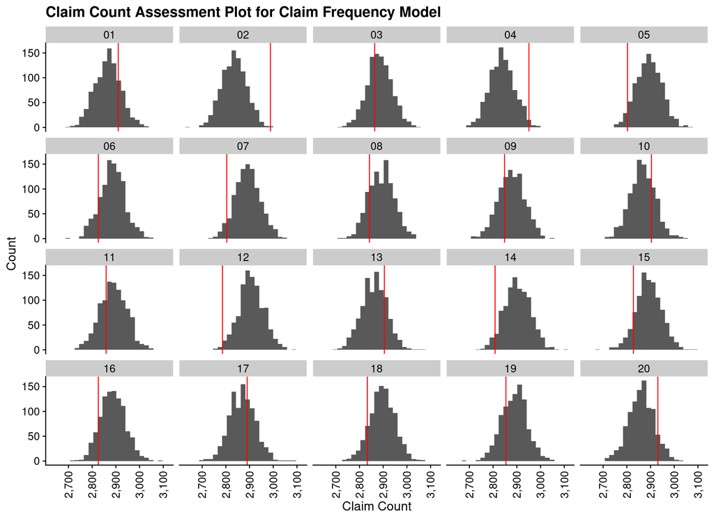

What about claim size?

VERY noisy…

Assume average claim size

```r
claim_tbl %>%
  filter(claim_amount <= 25000) %>%
  summarise(mean_amount = mean(claim_amount))
```

```
## # A tibble: 1 x 1
##   mean_amount
##         <dbl>
## 1       1415.
```

Use this for claim prediction

## Calculate Large Loss Charge

Estimate large losses per unit exposure

Power-law scaling factor

$\alpha = 2.7261483$

Use to estimate mean of distribution

$\mu = 59,460$

| Quantity | Value |
| --- | --- |
| Loss Expectation | 59,460 |
| Large Claim Proportion | 0.000487 |
| Large-loss Charge | 29 |

## Create Premium Quoter Function

| policy_id | expect_price | largeloss_charge | risk_premium | quote_price |
| --- | --- | --- | --- | --- |
| 100009 | 134.06 | 28.98 | 163.04 | 220.11 |
| 10001 | 95.82 | 28.98 | 124.81 | 168.49 |
| 100015 | 95.04 | 28.98 | 124.02 | 167.43 |
| 100019 | 196.43 | 28.98 | 225.41 | 304.31 |
| 100024 | 71.27 | 28.98 | 100.25 | 135.34 |
| 100026 | 9.09 | 28.98 | 38.07 | 51.40 |
| 100028 | 99.35 | 28.98 | 128.33 | 173.25 |
| 100038 | 16.77 | 28.98 | 45.75 | 61.77 |
| 100042 | 71.28 | 28.98 | 100.26 | 135.36 |
| 100045 | 54.23 | 28.98 | 83.21 | 112.34 |
| 100049 | 71.45 | 28.98 | 100.43 | 135.58 |
| 10005 | 125.16 | 28.98 | 154.14 | 208.09 |
| 100054 | 13.94 | 28.98 | 42.92 | 57.95 |
| 100057 | 78.60 | 28.98 | 107.59 | 145.24 |
| 100059 | 68.20 | 28.98 | 97.18 | 131.20 |
| 100063 | 124.38 | 28.98 | 153.37 | 207.05 |
| 100065 | 49.91 | 28.98 | 78.89 | 106.50 |
| 100071 | 52.98 | 28.98 | 81.97 | 110.65 |
| 100077 | 67.15 | 28.98 | 96.14 | 129.79 |
| 100079 | 61.56 | 28.98 | 90.55 | 122.24 |

# Pricing Assessment

## Test-Run Assessment Method

Claim rate

Claim size

Loss cost

### Assess Training Data

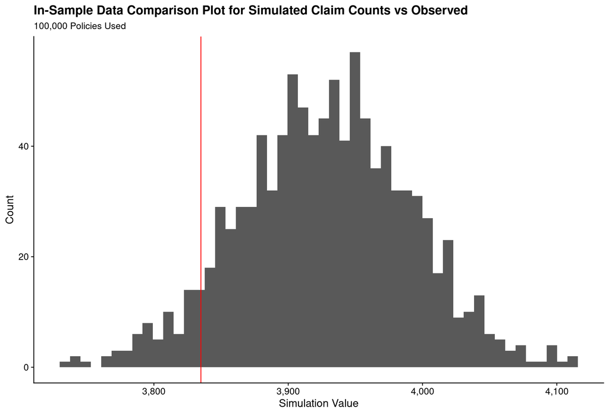

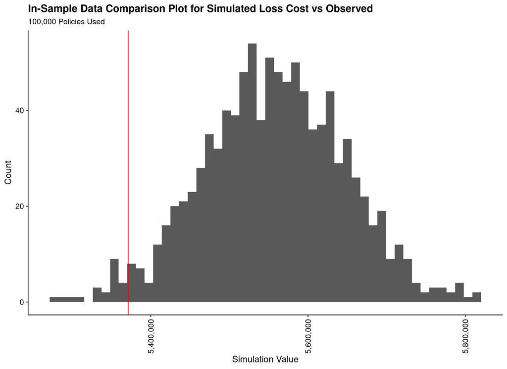

### Assess Out-of-Sample Data

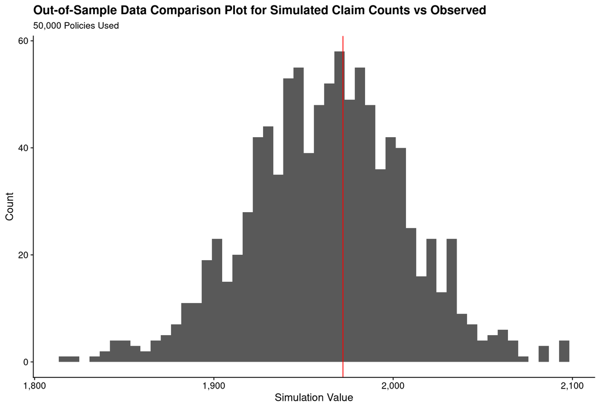

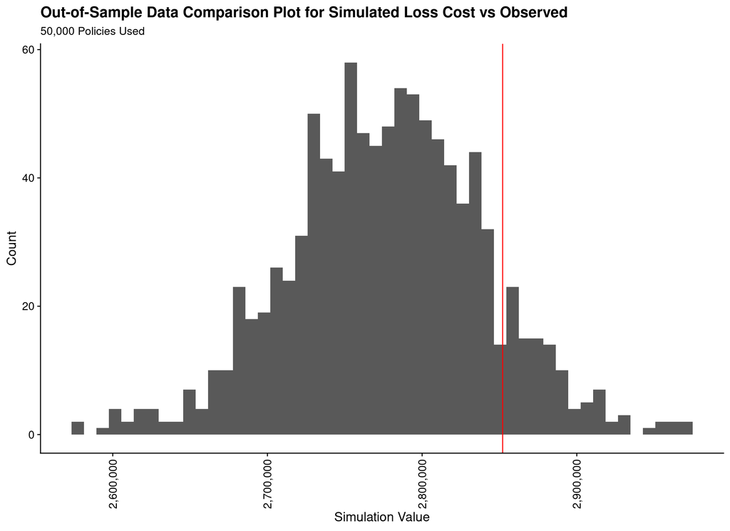